# Course Project 1 - Reproducible Research

Victoria D.

12/1/2017

## Loading the data

```r
data <- read.csv("activity.csv")
```

### First look at the data

```r
head(data)
```

```
##   steps       date interval
## 1    NA 2012-10-01        0
## 2    NA 2012-10-01        5
## 3    NA 2012-10-01       10
## 4    NA 2012-10-01       15
## 5    NA 2012-10-01       20
## 6    NA 2012-10-01       25
```

```r
summary(data)
```

```
##      steps                date          interval
##  Min.   :  0.00   2012-10-01:  288   Min.   :   0.0
##  1st Qu.:  0.00   2012-10-02:  288   1st Qu.: 588.8
##  Median :  0.00   2012-10-03:  288   Median :1177.5
##  Mean   : 37.38   2012-10-04:  288   Mean   :1177.5
##  3rd Qu.: 12.00   2012-10-05:  288   3rd Qu.:1766.2
##  Max.   :806.00   2012-10-06:  288   Max.   :2355.0
##  NA's   :2304     (Other)   :15840
```

# What is mean total number of steps taken per day?

Total number of steps taken per day

```r
steps_per_day <- aggregate(steps ~ date, data, sum)
```

Histogram of the total number of steps taken each day

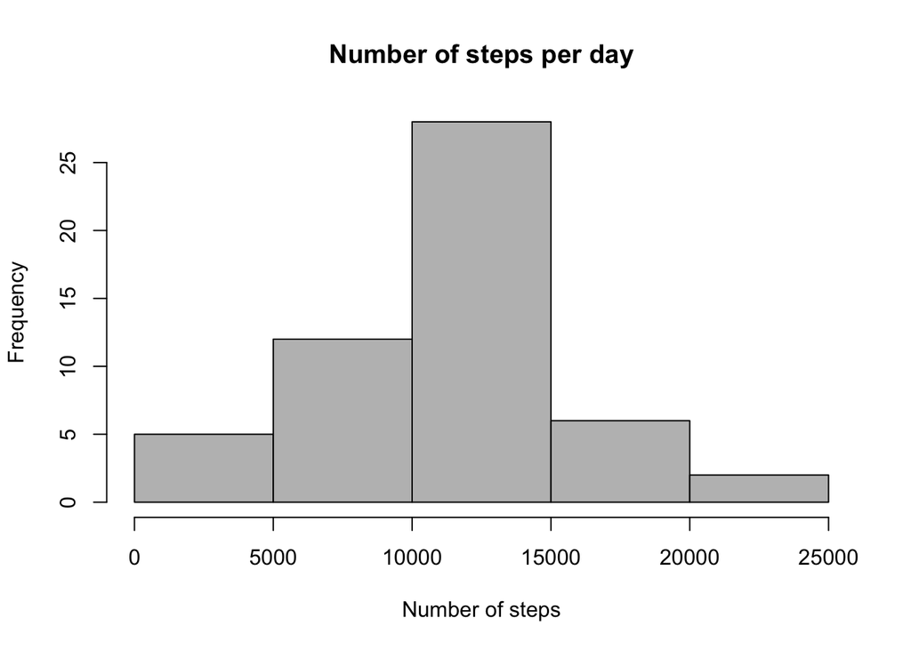

```r
hist(steps_per_day$steps, main = "Number of steps per day", xlab = "Number of steps", col = "gray")
```

```r
mean <- mean(steps_per_day$steps)
median <- median(steps_per_day$steps)
```

# What is the average daily activity pattern?

Time series plot of the 5-minute interval and the average number of steps taken, averaged across all days (y-axis)

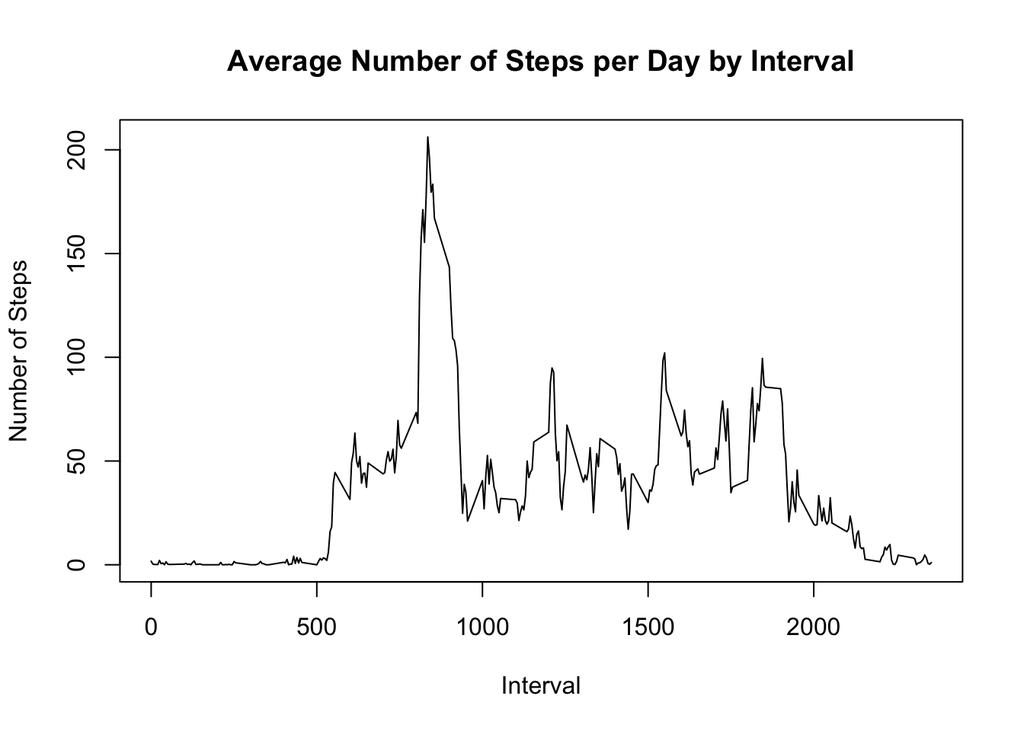

```r
steps_by_interval <- aggregate(steps ~ interval, data = data, FUN = "mean")

plot(steps_by_interval$interval,steps_by_interval$steps, type="l", xlab="Interval", ylab="Number of Steps",main="Average Number of Steps per Day by Interval")
```

```r
max <- steps_by_interval[which.max(steps_by_interval$steps),1]
```

# Imputing missing values

Total number of missing values in the dataset

```r
nas <- sum(!complete.cases(data))
```

The total number of missing values is: 2304.

Create a new dataset that is equal to the original dataset but with the missing data filled in.

```r
mean_int <- mean(steps_by_interval$steps)
data1 <- data
nas_index <- is.na(data[,1])
data1[nas_index,1] <- mean_int
head(data1)
```

```
##     steps       date interval
## 1 37.3826 2012-10-01        0
## 2 37.3826 2012-10-01        5
## 3 37.3826 2012-10-01       10
## 4 37.3826 2012-10-01       15
## 5 37.3826 2012-10-01       20
## 6 37.3826 2012-10-01       25
```

Histogram of the total number of steps taken each day

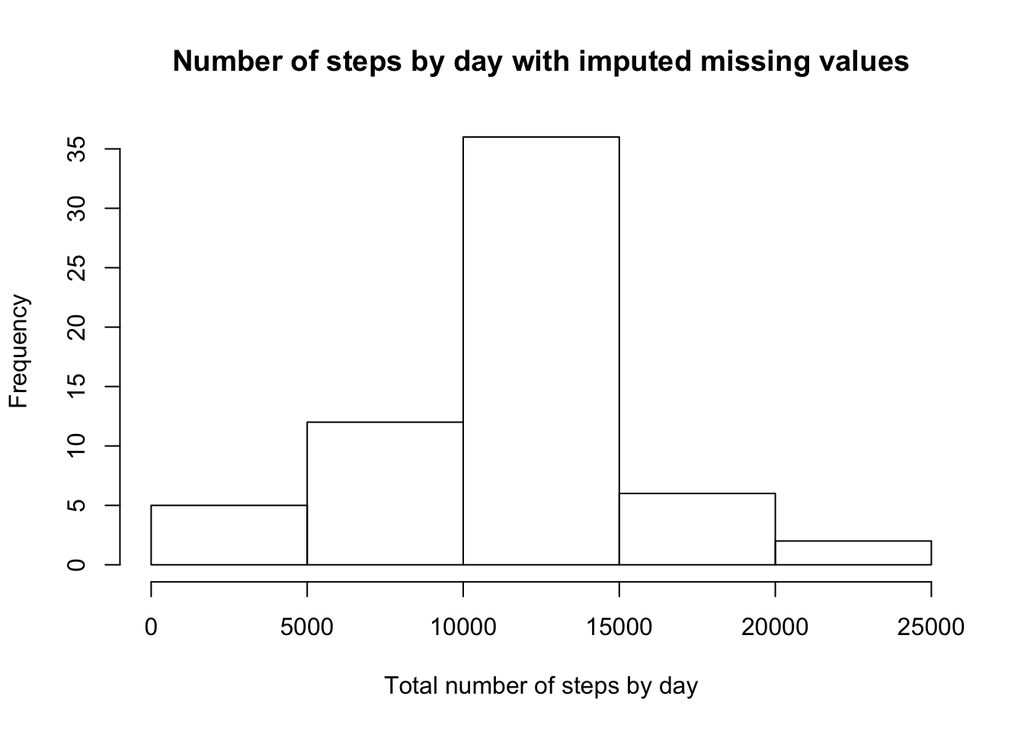

```r
steps_by_day1 <- aggregate(steps ~ date, data1, sum)
hist(steps_by_day1$steps, xlab = "Total number of steps by day", main = "Number of steps by day with imputed missing values")
```

```r
mean1 <- mean(steps_by_day1$steps)
median1 <- median(steps_by_day1$steps)
```

# Are there differences in activity patterns between weekdays and weekends?

Create a new factor variable in the dataset with two levels – “weekday” and “weekend” indicating whether a given date is a weekday or weekend day.

```r
data1$date <- as.Date(data1$date)

weekday <- function(d) {
  weekdays <- weekdays(d)
  ifelse (weekdays == "Saturday" | weekdays == "Sunday", "weekend", "weekday")
}

week <- sapply(data1$date, weekday)
data1$week <- as.factor(week)
head(data1)
```

```
##     steps       date interval    week
## 1 37.3826 2012-10-01        0 weekday
## 2 37.3826 2012-10-01        5 weekday
## 3 37.3826 2012-10-01       10 weekday
## 4 37.3826 2012-10-01       15 weekday
## 5 37.3826 2012-10-01       20 weekday
## 6 37.3826 2012-10-01       25 weekday
```

Make a panel plot containing a time series plot (i.e. 𝚝𝚢𝚙𝚎 = “𝚕”) of the 5-minute interval (x-axis) and the average number of steps taken, averaged across all weekday days or weekend days (y-axis). See the README file in the GitHub repository to see an example of what this plot should look like using simulated data.

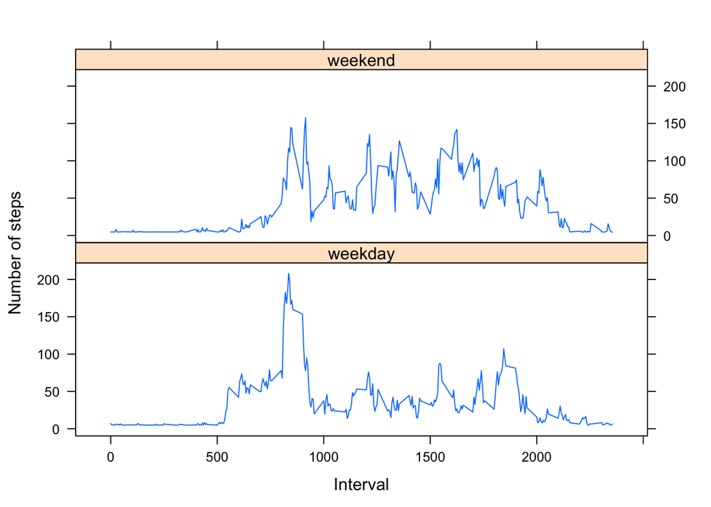

```r
data3 <- aggregate(steps ~ week+interval, data = data1, FUN = "mean")
library(lattice)
xyplot(steps ~ interval | factor(week),
       layout = c(1,2),
       xlab = "Interval",
       ylab = "Number of steps",
       type = "l",
       lty = 1,
       data = data3)
```